# Practical Machine Learning Course Project

Amanda Adler

March 25, 2018

Background: Using devices such as Jawbone Up, Nike FuelBand, and Fitbit it is now possible to collect a large amount of data about personal activity relatively. Individuals use these devices to quantify their activity level but rarely are the able to qunaity how well they perform the activities. The goal of this project is to use data from accelerometers on the belt, forearm, arm, and dumbell of 6 participants and create a model to predict whether participants perform barbell lifts correctly. They were asked to perform barbell lifts correctly and incorrectly in 5 different ways.

libraries

#### Load in the training dataset

```r
train <- read.csv("pml-training.csv",header=TRUE)
dim(train)
```

```
## [1] 19622   160
```

#### Load in the testing dataset

```r
test <- read.csv("pml-testing.csv", header=TRUE)
dim(test)
```

```
## [1]  20 160
```

```r
str(train)
```

```
## 'data.frame':    19622 obs. of  160 variables:
##  $ X                       : int  1 2 3 4 5 6 7 8 9 10 ...
##  $ user_name               : Factor w/ 6 levels "adelmo","carlitos",..: 2 2 2 2 2 2 2 2 2 2 ...
##  $ raw_timestamp_part_1    : int  1323084231 1323084231 1323084231 1323084232 1323084232 1323084232 1323084232 1323084232 1323084232 1323084232 ...
##  $ raw_timestamp_part_2    : int  788290 808298 820366 120339 196328 304277 368296 440390 484323 484434 ...
##  $ cvtd_timestamp          : Factor w/ 20 levels "02/12/2011 13:32",..: 9 9 9 9 9 9 9 9 9 9 ...
##  $ new_window              : Factor w/ 2 levels "no","yes": 1 1 1 1 1 1 1 1 1 1 ...
##  $ num_window              : int  11 11 11 12 12 12 12 12 12 12 ...
##  $ roll_belt               : num  1.41 1.41 1.42 1.48 1.48 1.45 1.42 1.42 1.43 1.45 ...
##  $ pitch_belt              : num  8.07 8.07 8.07 8.05 8.07 8.06 8.09 8.13 8.16 8.17 ...
##  $ yaw_belt                : num  -94.4 -94.4 -94.4 -94.4 -94.4 -94.4 -94.4 -94.4 -94.4 -94.4 ...
##  $ total_accel_belt        : int  3 3 3 3 3 3 3 3 3 3 ...
##  $ kurtosis_roll_belt      : Factor w/ 397 levels "","-0.016850",..: 1 1 1 1 1 1 1 1 1 1 ...
##  $ kurtosis_picth_belt     : Factor w/ 317 levels "","-0.021887",..: 1 1 1 1 1 1 1 1 1 1 ...
##  $ kurtosis_yaw_belt       : Factor w/ 2 levels "","#DIV/0!": 1 1 1 1 1 1 1 1 1 1 ...
```

[output cut: 86 more lines]

```r
str(test)
```

```
## 'data.frame':    20 obs. of  160 variables:
##  $ X                       : int  1 2 3 4 5 6 7 8 9 10 ...
##  $ user_name               : Factor w/ 6 levels "adelmo","carlitos",..: 6 5 5 1 4 5 5 5 2 3 ...
##  $ raw_timestamp_part_1    : int  1323095002 1322673067 1322673075 1322832789 1322489635 1322673149 1322673128 1322673076 1323084240 1322837822 ...
##  $ raw_timestamp_part_2    : int  868349 778725 342967 560311 814776 510661 766645 54671 916313 384285 ...
##  $ cvtd_timestamp          : Factor w/ 11 levels "02/12/2011 13:33",..: 5 10 10 1 6 11 11 10 3 2 ...
##  $ new_window              : Factor w/ 1 level "no": 1 1 1 1 1 1 1 1 1 1 ...
##  $ num_window              : int  74 431 439 194 235 504 485 440 323 664 ...
##  $ roll_belt               : num  123 1.02 0.87 125 1.35 -5.92 1.2 0.43 0.93 114 ...
##  $ pitch_belt              : num  27 4.87 1.82 -41.6 3.33 1.59 4.44 4.15 6.72 22.4 ...
##  $ yaw_belt                : num  -4.75 -88.9 -88.5 162 -88.6 -87.7 -87.3 -88.5 -93.7 -13.1 ...
##  $ total_accel_belt        : int  20 4 5 17 3 4 4 4 4 18 ...
##  $ kurtosis_roll_belt      : logi  NA NA NA NA NA NA ...
##  $ kurtosis_picth_belt     : logi  NA NA NA NA NA NA ...
##  $ kurtosis_yaw_belt       : logi  NA NA NA NA NA NA ...
```

[output cut: 86 more lines]

Many of the variables in the training dataset have missing values for nearly if not all of the observations. After doing further research on this topic, it seemed best to remove any predicitor with NA values. Also removed the first 7 colums as they are not appropriate to use as predictors.

```r
remove <- which(colSums(is.na(train)|train=="")>0*dim(train)[1])
train_new <- train[,-remove]
train_new <- train_new[,-c(1:7)]
dim(train_new)
```

```
## [1] 19622    53
```

#### Make same changes to testing dataset

```r
remove2 <- which(colSums(is.na(test)|test=="")>0*dim(test)[1])
test_new <- test[,-remove2]
test_new <- test_new[,-c(1:7)]
dim(test_new)
```

```
## [1] 20 53
```

#### Split training dataset into training and test datasets for model buidling purposes

```r
set.seed(2253)
part <- createDataPartition(train_new$classe, p=.75, list=FALSE)
train_final <- train_new[part,]
train_test <- train_new[-part,]
```

## Prediction Algorithms

We will use a classification tree model and random forest model

### Classification tree

For cross-validation, we used a 5-fold cross validation.

```r
cv <- trainControl(method = "cv", number = 5)
rpart <- train(classe ~ ., data =train_final, method = "rpart", trControl = cv)
```

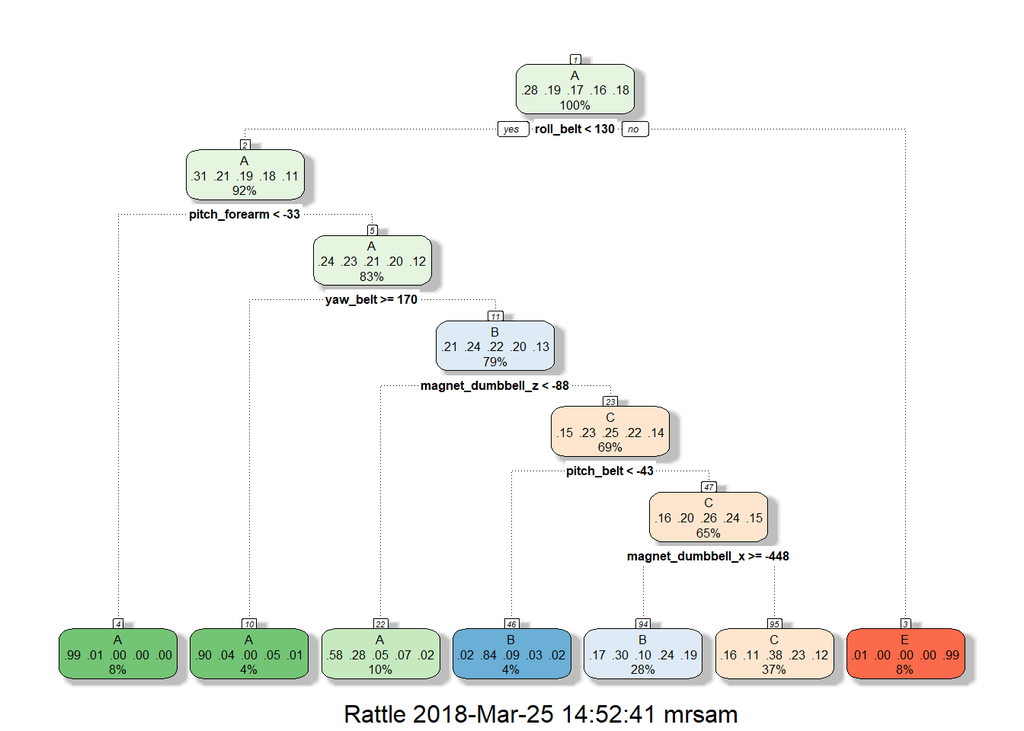

```r
fancyRpartPlot(rpart$finalModel)
```

Show model predictions using the validation data (testing partition of the training dataset)

```r
predict_rpart <- predict(rpart, train_test)
result_rpart <- confusionMatrix(train_test$classe, predict_rpart)
result_rpart
```

```
## Confusion Matrix and Statistics
##
##           Reference
## Prediction   A   B   C   D   E
##          A 833 244 316   0   2
##          B 158 577 214   0   0
##          C  22 165 668   0   0
##          D  50 318 436   0   0
##          E  11 294 196   0 400
##
## Overall Statistics
##
##                Accuracy : 0.5053
##                  95% CI : (0.4912, 0.5194)
##     No Information Rate : 0.3732
##     P-Value [Acc > NIR] : < 2.2e-16
##
##                   Kappa : 0.3774
##  Mcnemar's Test P-Value : NA
##
## Statistics by Class:
##
##                      Class: A Class: B Class: C Class: D Class: E
## Sensitivity            0.7756   0.3611   0.3650       NA  0.99502
## Specificity            0.8533   0.8875   0.9392   0.8361  0.88872
## Pos Pred Value         0.5971   0.6080   0.7813       NA  0.44395
## Neg Pred Value         0.9313   0.7418   0.7130       NA  0.99950
## Prevalence             0.2190   0.3259   0.3732   0.0000  0.08197
## Detection Rate         0.1699   0.1177   0.1362   0.0000  0.08157
## Detection Prevalence   0.2845   0.1935   0.1743   0.1639  0.18373
## Balanced Accuracy      0.8144   0.6243   0.6521       NA  0.94187
```

### Random Forests

```r
mod_rf <- train(classe ~ ., data = train_final, method = "rf", trControl=cv)
```

Show model predictions using the validation data (testing partition of the training dataset)

```r
predict_rf <- predict(mod_rf, train_test)
confusionMatrix(predict_rf, train_test$classe)$overall[1]
```

```
##  Accuracy
## 0.9914356
```

The accuracy of the random forests model was 99% meaning it was a much better model for prediciting the outcome than the classification tree model.

### We will now use the random forests model on the actual (cleaned) test data

```r
final_model <- predict(mod_rf, test_new)
```